# Phone Insurance

Randy Sherwood

Paying for phone insurance is something that has become pretty commonplace since the proliferation of smartphones. I suspect most people agree to the payments without thinking about it (heck, even though I declined it, my provider gave me “one month of free insurance” and I had to manually cancel it for the fee to not kick in automatically), which is why I decided to look into the practicality of the plans. This post has a lot of math (specifically, some basic game theory), but if you know how to plug values into a formula, you can benefit from it and determine whether or not it makes sense for you to insure your phone.

First things first: we need a payoff matrix that addresses all the possible outcomes of our decision. On our end, we can either buy insurance with a monthly cost (which I’ll leave variable, so you can adapt it to your provider’s plan), or we don’t. The part we don’t know is whether or not we’ll break our phones. Additionally, if we do break our phones, we don’t know how many times they’ll break. So the task is to generalize this decision strategy for all circumstances, and then you can make a decision about buying insurance based on whether or not you think you’re likely enough to use it.

Let c be the monthly cost of the insurance; let d be the deductible if we were to break the phone (this is often buried in fine print, so make sure to find it); let k be the number of times we break our phone; let x be the cost of replacing the phone without insurance; let n be the number of months we pay for insurance.

-If we insure the phone and it breaks, the payout is $-cn-dk$ ($c for insurance over n months, $d deductible for each phone)  
-If we insure the phone and it doesn’t break, the payout is $-cn$ (the cost of insurance, by itself)  
-If we don’t insure the phone and it breaks, the payout is $-xk$ (the cost of replacing k phones)  
-If we don’t insure the phone and it doesn’t break, the payout is $0$

The payout matrix is then:

|  | Breaks k times | Never Breaks |
| --- | --- | --- |
| With Insurance | -cn-dk | -cn |
| Without Insurance | -xk | 0 |

Now, the key to determining the optimal strategy is to determine at what point we become indifferent between our available strategies. So if we let p represent the probability of breaking our phones (k times), we generate the following equation:

$p(-cn-dk)+(1-p)(-cn) = p(-xk)+(1-p)(0)$

Since we want to know what the probability of breaking our phone would have to be in order to justify insurance, we solve for p:

$-cnp-dkp-cn+cnp = -xkp$ $-dkp-cn = -xkp$ $-dkp+xkp = cn$ $p(xk-dk) = cn$ $p = \frac{cn}{xk-dk}$ $p = \frac{cn}{(x-d)k}$

If you’re decent with math, you might recognize that this formula is basically “the cost of the plan divided by the additional cost we’d have to pay for all the replacement phones if we didn’t have insurance.”

Now that we have a formula, let’s consider some situations.

My provider’s fee is $10 a month (c=10), and the deductibe for my phone would be $175 (d=175). Suppose my history suggests I’d never break my phone more than once over the two years of my contract (k=1), and since I don’t know when that might happen, I’d have to insure it the entire time (n=24), and that I’d replace it with a brand new phone if I didn’t have insurance (x=650, the original MSRP, because I don’t want to assume that I’m not breaking it when it’s still at that price). Then:

$p = \frac{cn}{(x-d)k} = \frac{10*24}{(650-175)*1} = \frac{240}{475} \approx 50.5\%$

This means that, if there was a 50.5% chance of breaking my phone once, my expected payoff is the same whether I go with insurance or not. Knowing that, we can conclude the following: if I am more than 50.5% likely to break my phone, and I’d have to spend $650 to replace it without insurance, I should get insurance for the entire two years.

Now that you’re saying “wait, I’d never replace it with a brand new phone,” or “the cost of a phone drops over its lifetime,” let’s figure out the phone price at which insurance stops making any sense at all. In Game Theory, this is called a dominated strategy, and occurs when p is equal to or greater than 1. (It’s dominated because this is a situation where it never benefits you to choose the strategy.)

$\frac{240}{x-175} \geq 1$ $240 \geq x-175$ $415 \geq x$

This means that, if I can find a replacement for less than $415, and I’d only have to replace the phone once over two years, I should **absolutely not** purchase insurance. To demonstrate:

|  | Breaks Once | Doesn’t Break |
| --- | --- | --- |
| With Insurance | -415 | -240 |
| Without Insurance | >-415 | 0 |

As you can see, there is no outcome where insurance has a higher payout–it will always cost more.

Now, let’s look at the formula again:

$p = \frac{cn}{(x-d)k}$

The variable k, which represents the number of times we break the phone, is just a multiplier for the denominator. What this means is, if you were to break the phone twice, the probability of doing so would have to be half of what it was if you broke it once to be indifferent. So if I were to replace two broken phones with two new, identical phones, and keep insurance for the entire two years, the probability of doing this would only need to be higher than 50.5%/2 = 25.25% for insurance to be the smart decision. And for insurance to never make sense, I’d have to find two phones whose *average* cost was less than $415. If you were to break your phone thrice, you should really invest in a case.

The last variable to explore is n. We’ve established fairly well that insurance is a poor investment if you’re not likely to break your phones, but what if you ALWAYS break your phone? What if the expected lifespan of a phone in your possession is 10 months, and you REFUSE to get a rugged case for it? That’s what exploration of the variable $n$ will give us–n represents the number of months that we pay for insurance. Now, if you did the prior analysis and decided insurance is worthwhile for you, you might think “well, can’t I use a similar approach to decide how many months to insure the phone for?” The answer is no; the problem is that, if you don’t know when the phone might break, you risk insuring it for some set number of months, canceling insurance, breaking your phone the next month, and then possibly spending twice as much to replace it when you factor in the money you wasted on insurance you canceled. So the following approach should only be used to determine if you should insure the phone at all, knowing that you are going to break it. It’s essentially an analysis of “how often would I have to break my phone for insurance to save me money?” The complexity of this analysis, however, comes from determining the market value of a replacement phone in advance–this is a problem worthy of its own study in the field of economics. However, that doesn’t mean we can’t consider some scenarios.

Suppose that used phones end up being available relatively soon after release for $350 and we don’t deem it likely that we’ll break more than one phone. Using our formula, we can find the point at which p is greater than 1 to determine when insurance becomes a dominated strategy.

$\frac{10n}{350-175} \geq 1$ $\frac{10n}{175} \geq 1$ $10n \geq 175$ $n \geq \frac{175}{10}$ $n \geq 17.5$

This means that, in the 18th month (since n must be an integer), we would reach a point that insurance would cost us more than it would cost us to replace the phone outright. **Please note once more that this doesn’t mean that you should insure it for 18 months and then stop. If you were to break the phone in the 19th month, you’d basically have spent the cost of TWO replacement phones, because you’d have spent the equivalent on insurance that you never used. Instead, use this in your decision process. i.e. How likely are you to break the phone in the first 18 months?** In similar fashion, we can use the formula to determine the probability with which we’d need to break a phone in n months to make insurance worth consideration.

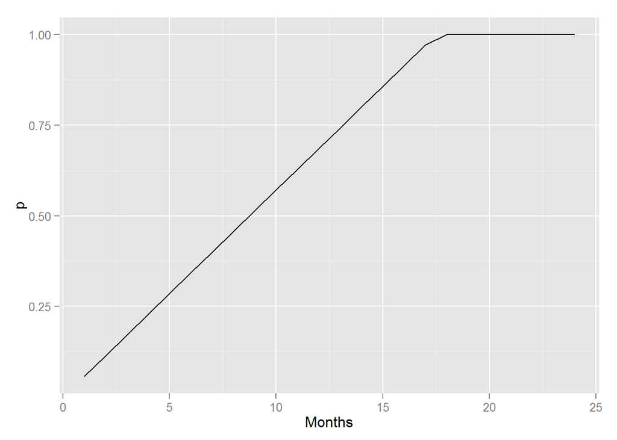

If we break it in the first month, it really benefits us to have insurance because we’d only spend $185 for a replacement-this is reflected by the fact that we’d need to be only 5.7% likely to break the phone in the first month for insurance to make sense. To keep insurance for 9 months, we’d have to be more than 50% likely to break the phone, though. And as we already covered, if we could find a replacement for $350 and would not break the phone more than once, it would only save us money if the replacement happened in the first 18 months.

Now, since we know it’s unreasonable to assume a constant market value over the course of two years, let’s assume some exponential decline in value. We can fit a model so that the value drops the most immediately (first used phones hit the market), and then levels out as the price is set by supply and demand. For the purposes of this discussion, let’s assume the value levels off in about a year at about $350 (coincidentally, that’s exactly what my device did–I could buy it today for $350).

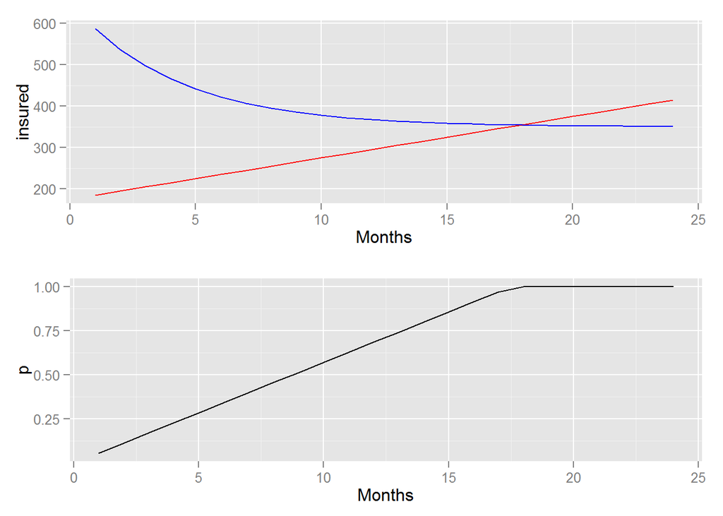

In this chart, the blue line denotes the value we’d pay for the replacement phone, out of pocket; the red line is how much we’d spend replacing one phone with insurance for n months (your deductible + plan cost * months); the black line in the bottom chart is the probability of breaking the phone for us to be indifferent between purchasing insurance and not. As you can see, p reaches 1 (insurance becomes dominated) at the same time that cost of insurance goes higher than the cost of replacing the phone.

So, if I have a history of breaking phones every 17 months or less, I would save money with insurance. If my phone will survive 18 months or more in my possession, insurance is a poor investment.

Now that we’ve established how to consider different replacement phone costs, a varying number of broken phones, and insuring for n months, you should have all the tools you need to make an informed decision about whether or not insurance is a good fit for you. If you’re not comfortable doing the filling in or manipulating the formula on your own, I created an [insurance calculator spreadsheet](https://dl.dropboxusercontent.com/u/37514313/Phone%20Insurance%20Calculator.xlsx) that you can download and enter your details into and see three different circumstances (if you buy a used phone assuming exponential decline in value, used phone with a constant decline in value, and if you spend full MSRP for a new phone).

Ultimately **only you** can determine for yourself whether insurance is a good idea, because only you know how prone to breaking phones you are. In a decade of owning a mobile phone, I’ve never had one break. So I would consider the likelihood of me breaking a phone to be so low that insurance is more likely to cost me money than to save me money. I’m certainly not likely to break multiple phones, so I’m not doing insurance. If you’ve broken a few phones in your day, do the math. How much do you think you can find a replacement for? What is YOUR probability of breaking one phone in during the course of a two year contract? (The number of broken phones divided by number of two year contracts you’ve signed [or the number of years you’ve had a mobile phone divided by two].) What’s the average lifespan of your phones? These aren’t hard calculations to do, and taking a few minutes to work with them can save you a lot of money.

And there’s another factor for you to consider personally-is it easier for you to pay $c a month and a $d deductible than the cost to replace the phone all at once? (This is why auto and medical insurance is necessary–most people can’t front $25,000 for medical or collision bills.) If you don’t have a credit card or a good financial cushion, perhaps dropping $400 on a used phone is scary to you. But in that case, I’d put my $c a month into a savings account, to soften the blow if a phone did break on me, and I’d buy a case to decrease that probability. At least then, if it doesn’t break, it’s still my money.

In conclusion, I’ll remind you of the formula, and urge you to take a few minutes thinking about this, before throwing your money away.

$p = \frac{cn}{(x-d)k}$

If you determine the probability of breaking your phone k times in n months and replacing it with a phone that costs x is higher than p, then get insurance. Otherwise, don’t.

[Return to Index](http://rsherwoodjr.github.io/index.html)